# Classification_Decision_Tree

### Bagging

Here we apply bagging to the Carseats data, using the randomForest package in R. The argument mtry = 10 indicates that all 10 predictors should be considered for each split of the tree—in other words, that bagging should be done.

```r
set.seed(1)
bag.Carseats <- randomForest(High ~ .- Sales, data = Carseats,subset = train, mtry = 10, importance = TRUE)
bag.Carseats
```

```
##
## Call:
##  randomForest(formula = High ~ . - Sales, data = Carseats, mtry = 10,      importance = TRUE, subset = train)
##                Type of random forest: classification
##                      Number of trees: 500
## No. of variables tried at each split: 10
##
##         OOB estimate of  error rate: 27.5%
## Confusion matrix:
##     No Yes class.error
## No  98  21   0.1764706
## Yes 34  47   0.4197531
```

Now to check how well does this bagged model perform on the test set.

```r
yhat.bag <- predict(bag.Carseats, Carseats.test, type = "class")
b.table<-table(yhat.bag,High.test)
b.table
```

```
##         High.test
## yhat.bag  No Yes
##      No  104  22
##      Yes  13  61
```

```r
(104+61)/(104+22+13+61)
```

```
## [1] 0.825
```

Now from bagging 82.5% of the test observations are correctly classified which is more than that we have obtained using an optimally-pruned single tree.

### Random Forest

Here we apply random forest to the Carseats data, using same randomForest package in R. Now we use √p variables when building a random forest of classification trees. Here we use mtry=3.

```r
set.seed(1)
rf.Carseats <-randomForest(High ~ .- Sales, data = Carseats, subset = train, mtry = 3, importance = TRUE)
yhat.rf <-predict(rf.Carseats, Carseats.test, type = "class")
r.table<-table(yhat.rf,High.test)
r.table
```

```
##        High.test
## yhat.rf  No Yes
##     No  110  24
##     Yes   7  59
```

```r
(110+59)/(110+59+7+24)
```

```
## [1] 0.845
```

We can see that from random forest 84.5% of the test observations are correctly classified which is more than bagging.

We can use the importance() function, to view the importance of each variable. From this function two measures of variable importance are reported. The first is based upon the mean decrease of accuracy in predictions on the out of bag samples when a given variable is permuted. The second is a measure of the total decrease in node impurity that results from splits over that variable, averaged over all trees.

```r
# to check importance
importance(rf.Carseats)
```

```
##                     No         Yes MeanDecreaseAccuracy MeanDecreaseGini
## CompPrice    2.1304913  2.21583500            3.0233624        11.332341
## Income      -1.2187382  0.08332858           -0.9127061        11.247612
## Advertising  2.7107740  9.28221142            8.0200032        11.539777
## Population  -2.5279538 -1.96748887           -3.4496266         9.515984
## Price       17.6102844 16.18029714           22.2205678        21.853751
## ShelveLoc   11.8799961 11.50873822           15.0797611        10.106813
## Age          3.7038805  6.83255965            6.9440472        11.738663
## Education   -2.9218854 -0.16331173           -2.5039109         6.031744
## Urban       -0.9337001  0.16405241           -0.4965739         1.114652
## US          -0.4330561  1.48555372            0.7195542         1.127466
```

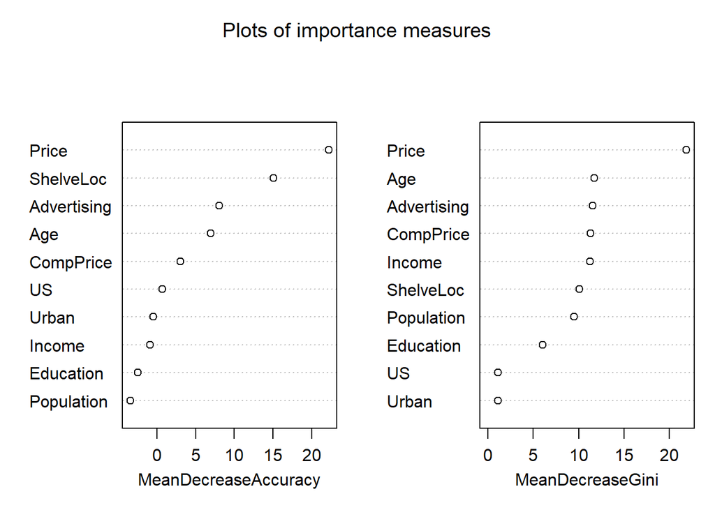

```r
#plot
varImpPlot(rf.Carseats,main = 'Plots of importance measures')
```

*Fig. 4 Plots of importance measures*

From Fig. 4 we can see that across all of the trees considered in the random forest, the Price company charges for car seats at each site (Price) is most important variables.

### Boosting

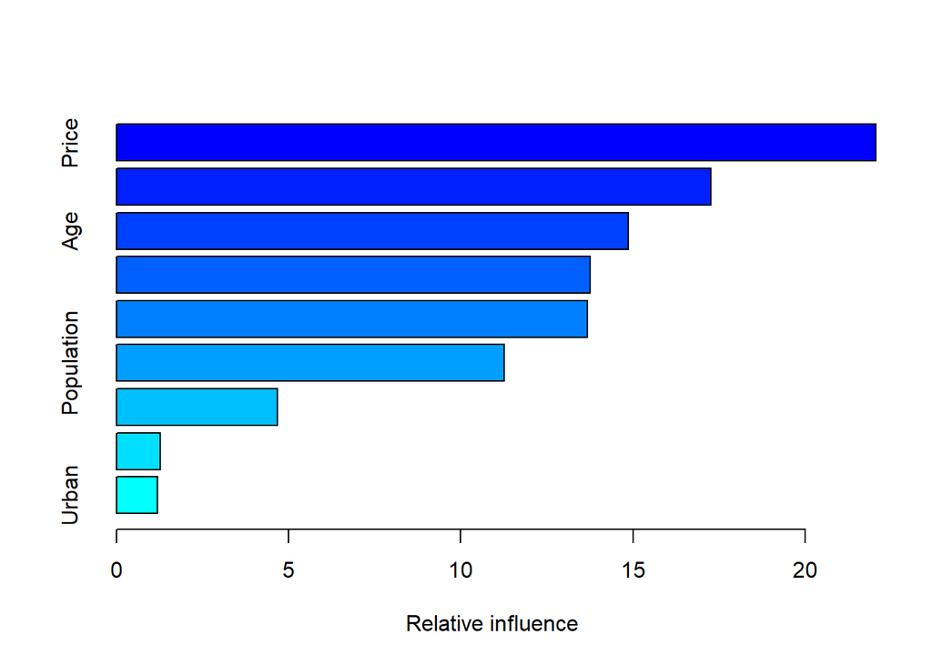

```
##                     var   rel.inf
## Price             Price 22.052626
## CompPrice     CompPrice 17.257112
## Age                 Age 14.870763
## Income           Income 13.756026
## Advertising Advertising 13.674207
## Population   Population 11.262025
## Education     Education  4.670754
## US                   US  1.268163
## Urban             Urban  1.188323
```

```r
library(gbm)
set.seed(1)
#to convert into dummy variable
d1<-data.frame(na.omit(Carseats[train,c('US', "High",'Urban') ]),stringsAsFactors=FALSE)
dyn<-ifelse(d1 == "Yes",1,0)
c.train<-Carseats[train, ]
boost.d1<-c.train[,-c(10:12)]
boost.d2<-boost.d1[,-7]
carseat.d<-data.frame(boost.d2,dyn)

boost.Carseats <- gbm(High ~ .- Sales, data = carseat.d, distribution = "bernoulli", n.trees = 5000, interaction.depth = 4)
summary(boost.Carseats)
```

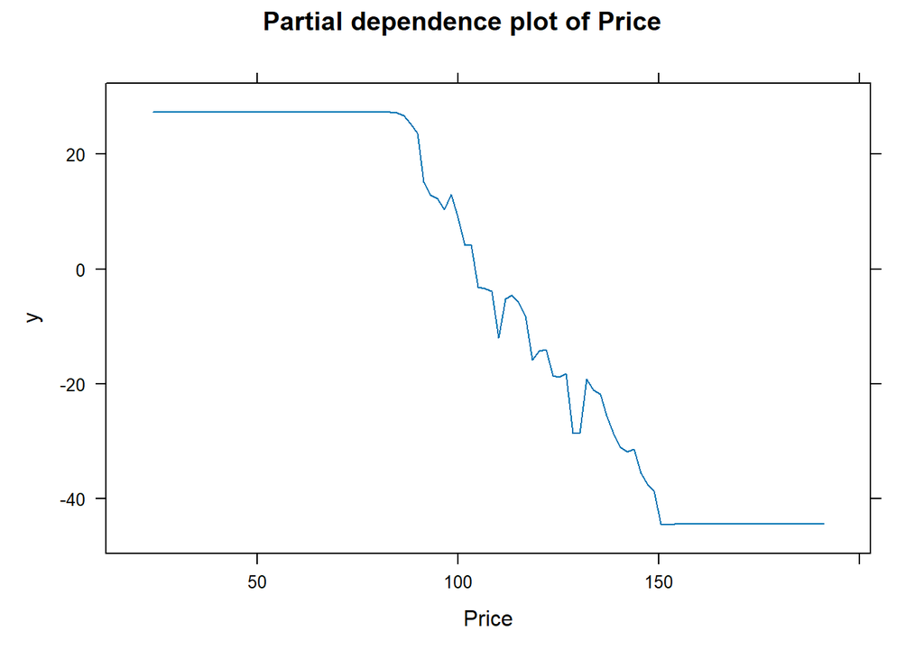

```r
plot(boost.Carseats, i = "Price", main='Partial dependence plot of Price')
```

*Fig. 5 Partial dependence plot of Price*